# Uebung C

RaumAn2 RaumAn

Dichteverteilungen

Patrick Laube , Nils Ratnaweera , Nikolaos Bakogiannis  
08-19-2021

```r
library(gstat)
library(sf)
library(tidyverse)
library(lubridate)
library(stars)

luftqualitaet <- read_sf("luftqualitaet.gpkg")
kantone <- read_sf("kantone.gpkg")
rotmilan <- read_sf("rotmilan.gpkg")


luftqualitaet <- st_set_crs(luftqualitaet,2056)
kantone <- st_set_crs(kantone, 2056)
rotmilan <- st_set_crs(rotmilan, 2056)
```

## Aufgabe 4: Rotmilan Bewegungsdaten visualisieren

Die erste Frage, die bei solchen Bewegungsstudien typischerweise gestellt wird, lautet: *Wo hält sich das Tier hauptsächlich auf?* Um diese Frage zu beantworten, kann man als erstes einfach die Datenpunkte in einer einfachen Karte visualisieren.

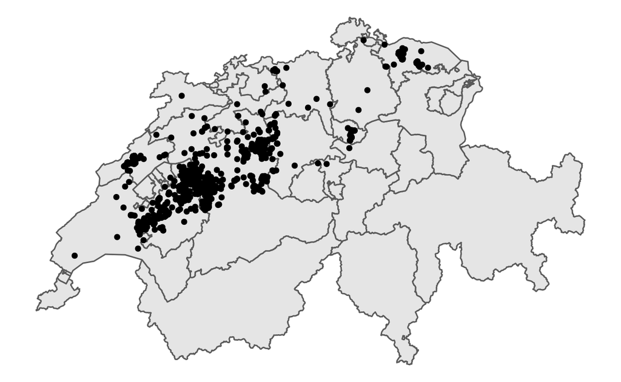

```r
ggplot(kantone) +
  geom_sf() +
  geom_sf(data = rotmilan) +
  theme_void()
```

## Aufgabe 5: Kernel Density Estimation berechnen

In einer ersten Annäherung funktioniert dies, doch wir sehen hier ein klassisches Problem des “Overplotting”. Das heisst, dass wir durch die Überlagerung vieler Punkte in den dichten Regionen nicht abschätzen können, wie viele Punkte dort effektiv liegen und ggf. übereinander liegen. Es gibt hier verschiedene Möglichkeiten, die Punktdichte klarer zu visualisieren. Eine unter Biologen sehr beliebte Methode ist die Dichteverteilung mit einer Kernel Density Estimation (KDE). Dies v.a. darum, weil mit KDE das Habitat (Streifgebiet) eines Tieres abgeschätzt werden kann. Homeranges werden oft mit KDE95 und Core Areas mit KDE50 definiert ([Fleming C., Calabrese J., 2016](https://besjournals.onlinelibrary.wiley.com/doi/full/10.1111/2041-210X.12673)).

Ähnlich wie beim IDW sind auch die verfügbaren KDE-Funktionen in R etwas kompliziert in der Handhabung. Damit wir dieses Verfahren aber dennoch auf unsere Rotmilan-Daten anwenden können, haben wir eine eigene KDE-Funktion erstellt, die wir Euch zur Verfügung stellen. Die Funktion beruht auf den Libraries `MASS`, `raster`, `sf` und `stars`. Die letzen drei solltet Ihr bereits installiert haben. Überprüft nun, ob `MASS` ebenfalls schon installiert ist und holt dies bei Bedarf nach. Im Anschluss könnt Ihr die nachstehende Funktion einlesen:

```r
my_kde <- function(points,cellsize, bandwith, extent = NULL){
  require(MASS)
  require(raster)
  require(sf)
  require(stars)
  if(is.null(extent)){
    extent_vec <- st_bbox(points)[c(1,3,2,4)]
  } else{
    extent_vec <- st_bbox(extent)[c(1,3,2,4)]
  }

  n_y <- ceiling((extent_vec[4]-extent_vec[3])/cellsize)
  n_x <- ceiling((extent_vec[2]-extent_vec[1])/cellsize)

  extent_vec[2] <- extent_vec[1]+(n_x*cellsize)-cellsize
  extent_vec[4] <- extent_vec[3]+(n_y*cellsize)-cellsize

  coords <- st_coordinates(points)
  matrix <- kde2d(coords[,1],coords[,2],h = bandwith,n = c(n_x,n_y),lims = extent_vec)
  raster(matrix)
}
```

Die Parameter der Funktion sollten relativ klar sein:

- `points`: Ein Punktdatensatz aus der Class `sf`
- `cellsize`: Die Zellgrösse des output-Rasters
- `bandwith`: Der Suchradius für die Dichteberechnung
- `extent` (optional): Der Perimeter, in dem die Dichteverteilung berechnet werden soll. Wenn kein Perimeter angegeben wird, wird die “bounding box” von `points` genutzt.

Wenn wir nun mit `my_kde()` die Dichteverteilung berechnen, erhalten wir einen Raseterdatensatz zurück, der sich mit `base::plot()` schnell visualisieren lässt.

```r
schweiz <- st_union(kantone)
rotmilan_kde <- my_kde(rotmilan,cellsize = 1000,bandwith = 10000, extent = schweiz)

rotmilan_kde
```

```
class      : RasterLayer
dimensions : 221, 349, 77129  (nrow, ncol, ncell)
resolution : 1000, 1000  (x, y)
extent     : 2484924, 2833924, 1074768, 1295768  (xmin, xmax, ymin, ymax)
crs        : NA
source     : memory
names      : layer
values     : 0, 1.125546e-08  (min, max)
```

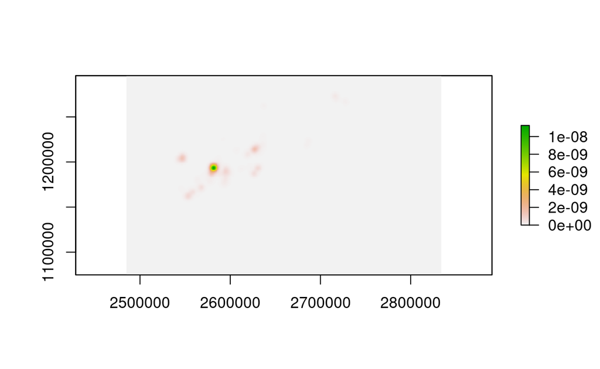

```r
plot(rotmilan_kde)
```

Um den Raster-Datensatz in `ggplot()` zu integrieren, müssen wir ihn zu einem `stars`-Objekt konvertieren und können danach `geom_stars()` verwenden.

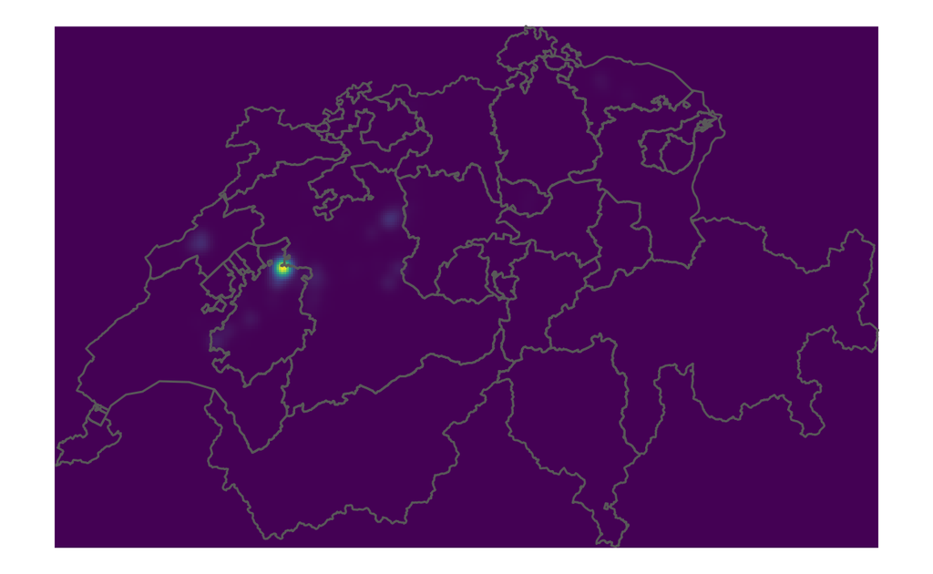

```r
ggplot() +
  geom_stars(data = st_as_stars(rotmilan_kde)) +
  geom_sf(data = kantone, fill = NA) +
  scale_fill_viridis_c() +
  theme_void() +
  theme(legend.position = "none")
```

Die Kernel Density Estimation ist nun sehr stark von den tiefen Werten dominiert, da die Dichte in den meisten Zellen unseres Untersuchungsgebiets nahe bei Null liegt.

Wir können die tiefen Werte ausblenden, indem wir nur die höchsten 5% der Werte darstellen. Dafür berechnen wir mit `raster::quantile` die 95. Perzentile aller Rasterzellen und nutzen dies um die Farbskala in `ggplot` zu limitieren (*KDE95*). Zusätzlich hilft eine logarithmische Transformation der KDE-Werte, die Farbskala etwas sichtbarer zu machen.

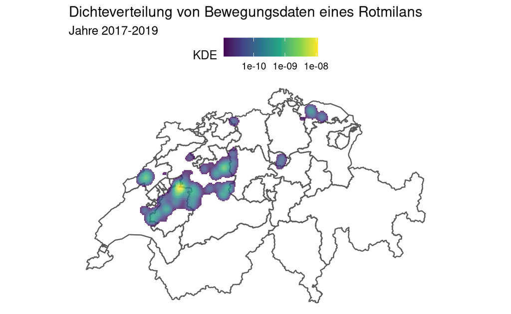

```r
q95 <- raster::quantile(rotmilan_kde,probs = 0.95)

ggplot() +
  geom_sf(data = kantone, fill = NA) +
  geom_stars(data = st_as_stars(rotmilan_kde),alpha = 0.8) +
  scale_fill_viridis_c(trans = "log10",limits = c(q95,NA),na.value = NA) +
  theme_void() +
  labs(fill = "KDE",title = "Dichteverteilung von Bewegungsdaten eines Rotmilans",subtitle = "Jahre 2017-2019") +
  theme(legend.position = "top", legend.direction = "horizontal")
```

## Aufgabe 6: Dichteverteilung mit Thiessen Polygonen

Thiessen Polygone bieten eine spannende Alternative um Unterschiede in der Dichteverteilung von Punktdatensätzen zu visualisieren. Wir wollen dies nun ausprobieren und konstruieren zum Schluss die Thiessenpolygone für die Rotmilan-Daten für das Untersuchungsgebiet Schweiz.

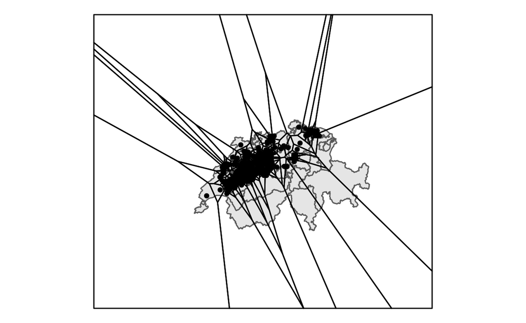

```r
thiessenpolygone <- rotmilan %>%
  st_union() %>%
  st_voronoi()

ggplot() +
  geom_sf(data = kantone) +
  geom_sf(data = thiessenpolygone, fill = NA) +
  geom_sf(data = rotmilan) +
  theme_void()
```

```r
schweiz <- st_union(kantone)


thiessenpolygone
```

```
Geometry set for 1 feature
Geometry type: GEOMETRYCOLLECTION
Dimension:     XY
Bounding box:  xmin: 2285390 ymin: 920063.6 xmax: 2958708 ymax: 1505862
Projected CRS: CH1903+ / LV95
```

```r
thiessenpolygone <- st_cast(thiessenpolygone)

thiessenpolygone
```

```
Geometry set for 4365 features
Geometry type: POLYGON
Dimension:     XY
Bounding box:  xmin: 2285390 ymin: 920063.6 xmax: 2958708 ymax: 1505862
Projected CRS: CH1903+ / LV95
First 5 geometries:
```

```r
# Dieser Schritt kann eine Weile dauern
thiessenpolygone_clip <- st_intersection(thiessenpolygone,schweiz)
```

Wenn wir jetzt die Thiessenpolygone (ohne Punkte) darstellen, wird deutlicher, wie die Dichteverteilung im Innern des Clusters aussieht.

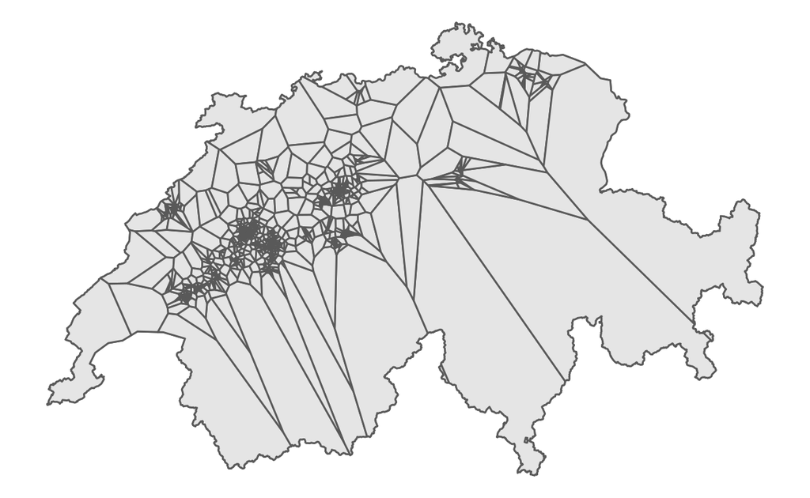

```r
ggplot() +
  geom_sf(data = schweiz) +
  geom_sf(data = thiessenpolygone_clip) +
  theme_void()
```